# Conociendo Rstudio

Jorge Meneses

Paulo Peña

Rstudio es la principal aplicación para usar R. En esta sesión empezaremos por conocer la interface y como podemos utilizarla.

# Paneles Clave RStudio

Rstudio tiene los siguientes 4 paneles o áreas claves:

- Source Code o Editor de Código es la fuente donde escribes tú código. La información escrita puede ser luego almacenada, modificada y compartida con otros usuarios.
- Console o Consola donde se presenta los resultados de las operaciones que comandamos en el guión.
- El ambiente o Environment donde almacenamos los objetos que vamos creando como tablas, bases de datos o funciones.
- Files/Plots/Packages/Help, donde puedes ver tus archivos de la computadora, gráficos, paquetes (esto lo veremos luego) y archivos de ayuda.

## Source Code/Editor de Código

Done se crea y edita los códigos de R. Aunque esrtos archivos se guardan con la extensión “.R”, estos solo son archivos de texto. Los resultados del código se verán en el panel de Consola.

El guión cuenta el número de línea donde se está escribiend el código. Para escribir anotaciones en el guión, se debe anteceder la línea con el símbolo “#”. También se puede dividir el guión secciones con “#####” haciéndo más fácil la navegación dentro del guión.

El editor de código será nuestro principal espacio de trabajo. Aquí podemos escribir todas las instrucciones para realizar nuestros análisis y reportes.

El guión se puede ejecutar por líneas o completo. Si solo quiere ejecutar unas líneas, se debe seleccionar las líneas deseadas y apretar el botón Enter o también en el extremos derecho del panel se encuentra la opción “Run”. Si se desea ejecutar todo un guión, en el extremos derecho del panel se selecciona la opción “Source”.

Guión R

[figure not shown]

## Consola

La consola de R es el área donde se presentan los resultados del código que hemos ejecutado. Si hay algún error en el código escrito, la consola nos indicará sobre dicho error. Existen diferentes tipos de errores, pueden ser desde algo simple como un signo de puntuación mal puesto hasta cosas más complejas como falta de archivos en la computadora.

Adicionalmente, también se puede colocar líneas de código directa en la consola y el programa ejecutará los comandos, sin embargo, estas líneas de códigos no serán grabadas.

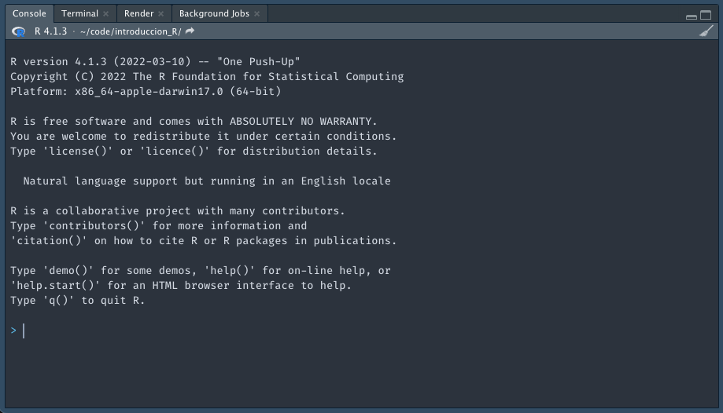

Consola R

## Ambiente o Environment

[figure not shown]

## El panel de ayuda, gráficos (plots), archivos

# Tipo de Variables en RStudio

Creación de variables

Tarea: un guión con un conjunto de variables, una de cada tipo